# Test Realm and Keeper of the YAML

August 04, 2022

## Market for Loanable Funds

- The **Market for Loanable Funds** looks at the **supply** of loans and the **demand** for borrowing.
- The **price** in this market is the **nominal interest rate**.
- We start with this market in equilibrium of **private** borrowing only: D<sub>1</sub> only includes demand from the private sector.
- The amount of **private borrowing** is Q<sub>1</sub>.

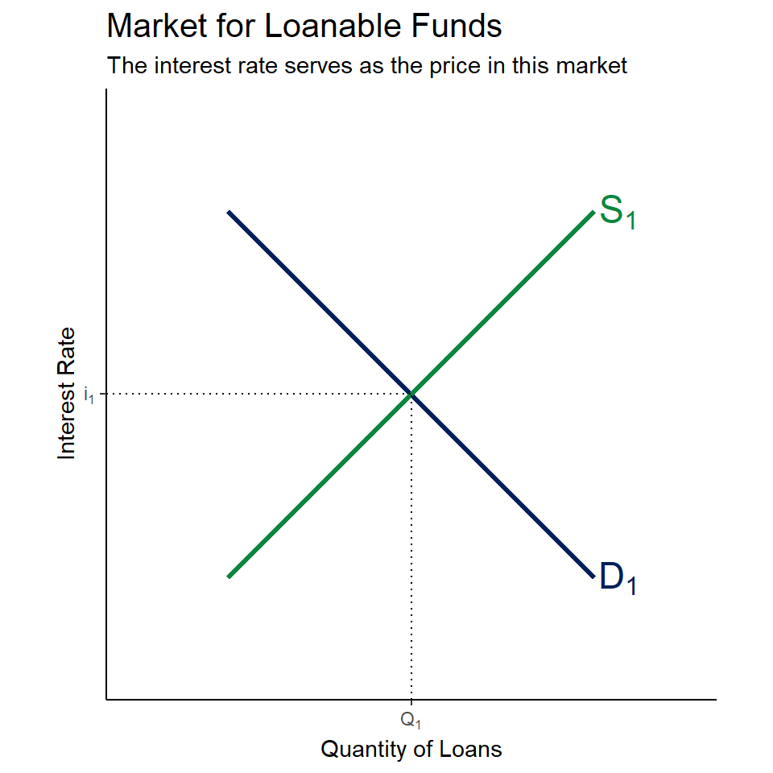

## Market for Loanable Funds

- Increased government borrowing shifts demand to D<sub>2</sub>.
- Demand shifting right **increases** interest rates to i<sub>2</sub>.
- At i<sub>2</sub>, **total** borrowing increases to Q<sub>2</sub>, but this includes both public and private borrowing.

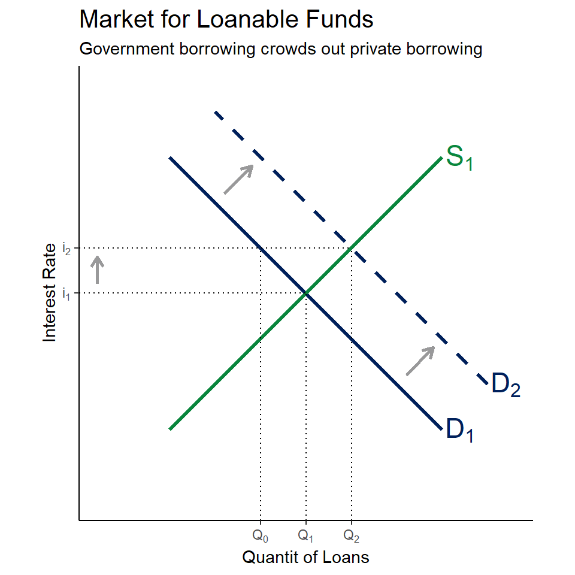

## Market for Loanable Funds

- Recall that D<sub>1</sub> is still **private** borrowing demand, so Q<sub>0</sub> is the amount of private borrowing.
- Q<sub>2</sub> - Q<sub>0</sub> is government borrowing, but some of that government borrowing is **crowding out** private borrowing that would have happened had the interest rate been lower!
- Q<sub>1</sub> - Q<sub>0</sub> is the amount of private borrowing that has been crowded out.

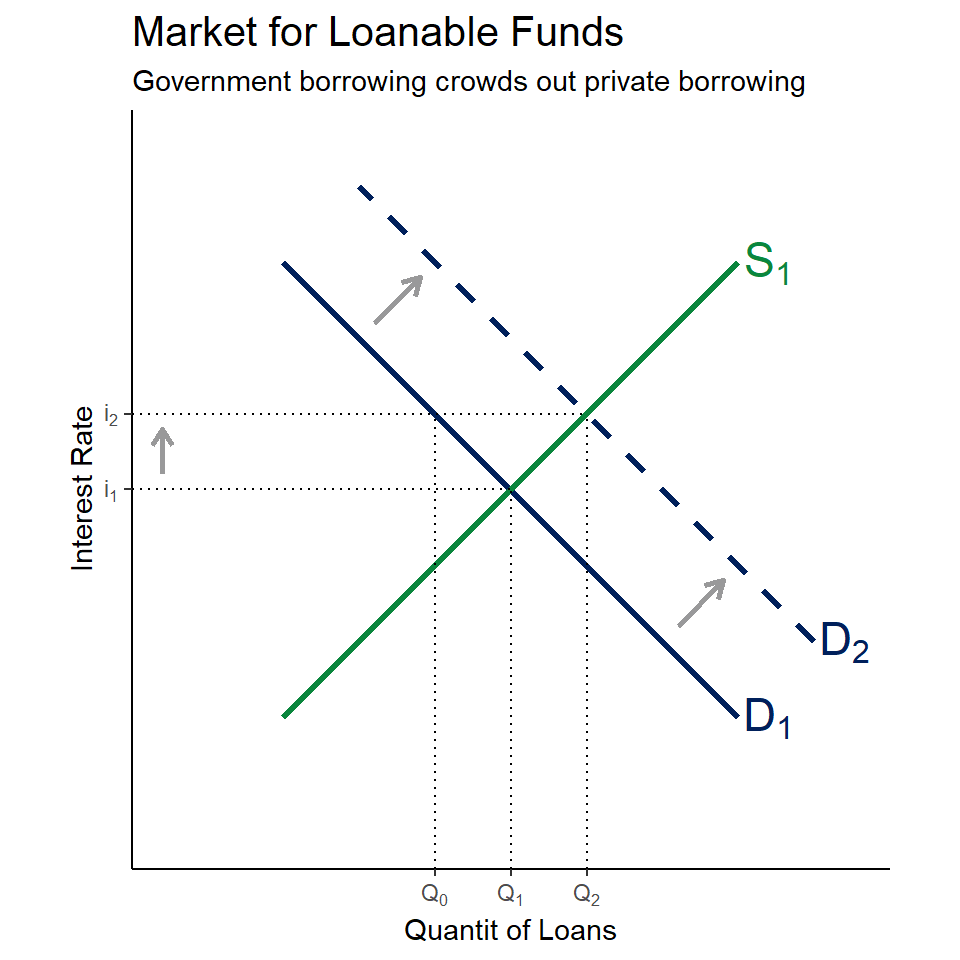

## Recessions

In the summer of 2022, there was a major political battle in the US over the definition of a recession.

Consider this tweet from a Fox News anchor in advance of the Second Quarter’s GDP announcement:

[figure not shown]